# Introduction

# How Does Adam Work?

Adam is different to classical stochastic gradient descent.

Stochastic gradient descent maintains a single learning rate (termed alpha) for all weight updates and the learning rate does not change during training.

A learning rate is maintained for each network weight (parameter) and separately adapted as learning unfolds.

Adam is combination of the advantages of two other extensions of stochastic gradient descent:

- **Adaptive Gradient Algorithm** that maintains a per-parameter learning rate that improves performance on problems with sparse gradients (e.g. natural language and computer vision problems).
- **Root Mean Square Propagation** that also maintains per-parameter learning rates that are adapted based on the average of recent magnitudes of the gradients for the weight (e.g. how quickly it is changing). This means the algorithm does well on online and non-stationary problems (e.g. noisy).

Adam realizes the benefits of both AdaGrad and RMSProp.

Instead of adapting the parameter learning rates based on the average first moment (the mean) as in RMSProp, Adam also makes use of the average of the second moments of the gradients (the uncentered variance).

```python
input_layer = layers.Input(shape=(80,80,1))
output_layer = layers.Flatten()(input_layer)
output_layer = layers.Dense(100, activation='relu')(output_layer)
output_layer = layers.Dense(100, activation='relu')(output_layer)
output_layer = layers.Dense(3, activation='softmax')(output_layer)
model = models.Model(inputs=input_layer, outputs=output_layer)
model.compile(optimizer=optimizers.Adam(learning_rate=0.001), loss='categorical_crossentropy', metrics=['accuracy', Recall, Precision, F1])
history = model.fit(train_data, validation_data=test_data , epochs=10)
```

```python
loss, accuracy, recall, precision, f1 = model.evaluate(test_data, verbose=0)
print("Loss = ",loss)
print("Accuarcy = ",accuracy)
print("Recall = ",recall)
print("Precision = ",precision)
print("F1 = ",f1)
```

[output not shown]

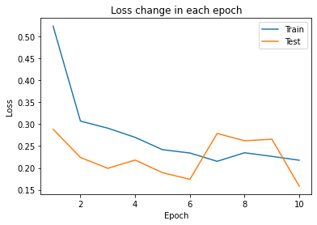

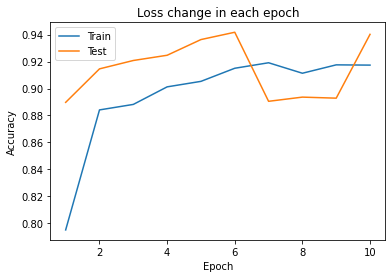

```python
plt.plot([1,2,3,4,5,6,7,8,9,10], history.history["loss"])
plt.plot([1,2,3,4,5,6,7,8,9,10], history.history["val_loss"])
plt.legend(["Train", "Test"])
plt.xlabel('Epoch')
plt.ylabel('Loss')
plt.title('Loss change in each epoch')
plt.show()
plt.plot([1,2,3,4,5,6,7,8,9,10], history.history["accuracy"])
plt.plot([1,2,3,4,5,6,7,8,9,10], history.history["val_accuracy"])
plt.legend(["Train", "Test"])
plt.xlabel('Epoch')
plt.ylabel('Accuracy')
plt.title('Loss change in each epoch')
plt.show()
```

As we can see in result, our recall is decreased and our loss is increased and at all we had better result without adam. Also I should mention that this happened here but for real bigger data, at all Adam is better and in that we have less loss values and more accuracy.

But here it is not like that, but there is noo that much different.

This difference maybe is because of change of learning rate.

```python
input_layer = layers.Input(shape=(80,80,1))
output_layer = layers.Flatten()(input_layer)
output_layer = layers.Dense(100, activation='relu')(output_layer)
output_layer = layers.Dense(100, activation='relu')(output_layer)
output_layer = layers.Dense(3, activation='softmax')(output_layer)
model = models.Model(inputs=input_layer, outputs=output_layer)
model.compile(optimizer=optimizers.Adam(learning_rate=0.001), loss='categorical_crossentropy', metrics=['accuracy', Recall, Precision, F1])
history = model.fit(train_data, validation_data=test_data , epochs=20)
```

```python
loss, accuracy, recall, precision, f1 = model.evaluate(test_data, verbose=0)
print("Loss = ",loss)
print("Accuarcy = ",accuracy)
print("Recall = ",recall)
print("Precision = ",precision)
print("F1 = ",f1)
```

[output not shown]

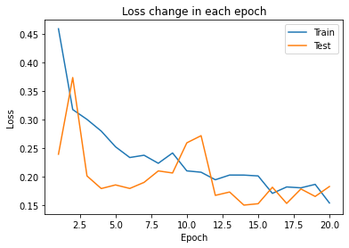

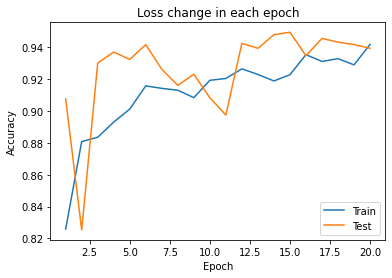

```python
plt.plot([1,2,3,4,5,6,7,8,9,10, 11, 12, 13, 14, 15, 16,17 ,18 ,19, 20], history.history["loss"])
plt.plot([1,2,3,4,5,6,7,8,9,10, 11, 12, 13, 14, 15, 16,17 ,18 ,19, 20], history.history["val_loss"])
plt.legend(["Train", "Test"])
plt.xlabel('Epoch')
plt.ylabel('Loss')
plt.title('Loss change in each epoch')
plt.show()
plt.plot([1,2,3,4,5,6,7,8,9,10, 11, 12, 13, 14, 15, 16,17 ,18 ,19, 20], history.history["accuracy"])
plt.plot([1,2,3,4,5,6,7,8,9,10, 11, 12, 13, 14, 15, 16,17 ,18 ,19, 20], history.history["val_accuracy"])
plt.legend(["Train", "Test"])
plt.xlabel('Epoch')
plt.ylabel('Accuracy')
plt.title('Loss change in each epoch')
plt.show()
```

## What Is an Epoch?

The number of epochs is a hyperparameter that defines the number times that the learning algorithm will work through the entire training dataset.

One epoch means that each sample in the training dataset has had an opportunity to update the internal model parameters. An epoch is comprised of one or more batches. For example, as above, an epoch that has one batch is called the batch gradient descent learning algorithm.

## Why to use more than one epoch?

I know it doesn’t make sense in the starting that — passing the entire dataset through a neural network is not enough. And we need to pass the full dataset multiple times to the same neural network. But keep in mind that we are using a limited dataset and to optimise the learning and the graph we are using Gradient Descent which is an iterative process. So, updating the weights with single pass or one epoch is not enough.

One epoch leads to underfitting of the curve in the graph (below).

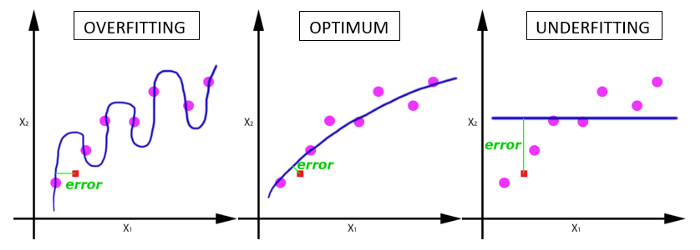

As we mentioned it is not necessary to use more than one epoch, because maybe we have a large enough dataset to train which does not happen so much in reality.

As the number of epochs increases, more number of times the weight are changed in the neural network and the curve goes from underfitting to optimal to overfitting curve.

To handle this situation the options are:

- We need to come-up with a simple model with less number of parameters to learn
- Add more data by augmentation
- Add noise to dense or convolution layers
- Add drop-out layers
- Add l1 or l2 regularizers
- Add early stopping
- Check the model accuracy on validation data
- Early stopping will tell you appropriate epochs without overfitting the model

```python
input_layer = layers.Input(shape=(80,80,1))
output_layer = layers.Flatten()(input_layer)
output_layer = layers.Dense(100, activation='relu')(output_layer)
output_layer = layers.Dense(100, activation='relu')(output_layer)
output_layer = layers.Dense(3, activation='softmax')(output_layer)
model = models.Model(inputs=input_layer, outputs=output_layer)
model.compile(optimizer=optimizers.Adam(learning_rate=0.001), loss=losses.mean_squared_error, metrics=['accuracy', Recall, Precision, F1])
history = model.fit(train_data, validation_data=test_data , epochs=20)
```

```python
loss, accuracy, recall, precision, f1 = model.evaluate(test_data, verbose=0)
print("Loss = ",loss)
print("Accuarcy = ",accuracy)
print("Recall = ",recall)
print("Precision = ",precision)
print("F1 = ",f1)
```

```
Loss =  0.2241200953722
Accuarcy =  0.6638198494911194
Recall =  0.6653963327407837
Precision =  0.6653963327407837
F1 =  0.6653962731361389
```

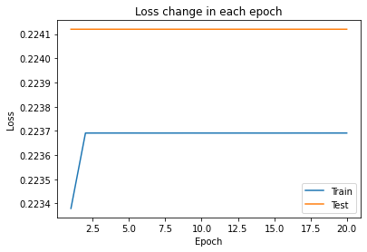

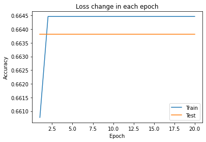

```python
plt.plot([1,2,3,4,5,6,7,8,9,10, 11, 12, 13, 14, 15, 16,17 ,18 ,19, 20], history.history["loss"])
plt.plot([1,2,3,4,5,6,7,8,9,10, 11, 12, 13, 14, 15, 16,17 ,18 ,19, 20], history.history["val_loss"])
plt.legend(["Train", "Test"])
plt.xlabel('Epoch')
plt.ylabel('Loss')
plt.title('Loss change in each epoch')
plt.show()
plt.plot([1,2,3,4,5,6,7,8,9,10, 11, 12, 13, 14, 15, 16,17 ,18 ,19, 20], history.history["accuracy"])
plt.plot([1,2,3,4,5,6,7,8,9,10, 11, 12, 13, 14, 15, 16,17 ,18 ,19, 20], history.history["val_accuracy"])
plt.legend(["Train", "Test"])
plt.xlabel('Epoch')
plt.ylabel('Accuracy')
plt.title('Loss change in each epoch')
plt.show()
```

## Why MSE is not good for classification?

As we see above, loss and accuracy does not change that much and also they does not have good values. So why this happens?

In the case of classification, we take the argmax of the probability of each training instance.

Now consider below example.

Our probability utputs are 0.49 and 0.51. So the class predicted is class 1. Now imagine that true label is also 1.

In such a case, if MSE is used, it will return 0 as a loss value, whereas the binary cross-entropy will return some "tangible" value. And, if somehow with all data samples, the trained model predicts a similar type of probability, then binary cross-entropy effectively return a big accumulative loss value, whereas MSE will return a 0.

MSE is usable in regresssion.

So we can see here `MSE` does not make enough Accuracy for us (And other metrics too).

```python
input_layer = layers.Input(shape=(80,80,1))
output_layer = layers.Flatten()(input_layer)
output_layer = layers.Dense(100, activation='relu')(output_layer)
output_layer = layers.Dropout(0.1)(output_layer)
output_layer = layers.Dense(100, activation='relu')(output_layer)
output_layer = layers.Dropout(0.1)(output_layer)
output_layer = layers.Dense(3, activation='softmax')(output_layer)
model = models.Model(inputs=input_layer, outputs=output_layer)
model.compile(optimizer=optimizers.Adam(learning_rate=0.001), loss='categorical_crossentropy', metrics=['accuracy', Recall, Precision, F1])
history = model.fit(train_data, validation_data=test_data , epochs=20)
```

```python
loss, accuracy, recall, precision, f1 = model.evaluate(test_data, verbose=0)
print("Loss = ",loss)
print("Accuarcy = ",accuracy)
print("Recall = ",recall)
print("Precision = ",precision)
print("F1 = ",f1)
```

```
Loss =  0.24277304112911224
Accuarcy =  0.9083850979804993
Recall =  0.9024389982223511
Precision =  0.9134784936904907
F1 =  0.9078712463378906
```

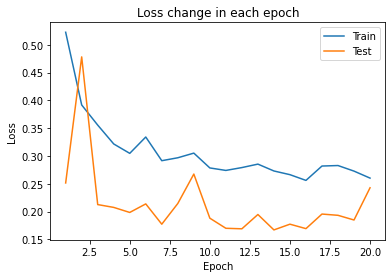

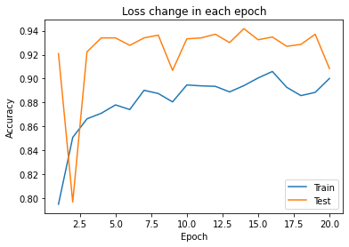

```python
plt.plot([1,2,3,4,5,6,7,8,9,10, 11, 12, 13, 14, 15, 16,17 ,18 ,19, 20], history.history["loss"])
plt.plot([1,2,3,4,5,6,7,8,9,10, 11, 12, 13, 14, 15, 16,17 ,18 ,19, 20], history.history["val_loss"])
plt.legend(["Train", "Test"])
plt.xlabel('Epoch')
plt.ylabel('Loss')
plt.title('Loss change in each epoch')
plt.show()
plt.plot([1,2,3,4,5,6,7,8,9,10, 11, 12, 13, 14, 15, 16,17 ,18 ,19, 20], history.history["accuracy"])
plt.plot([1,2,3,4,5,6,7,8,9,10, 11, 12, 13, 14, 15, 16,17 ,18 ,19, 20], history.history["val_accuracy"])
plt.legend(["Train", "Test"])
plt.xlabel('Epoch')
plt.ylabel('Accuracy')
plt.title('Loss change in each epoch')
plt.show()
```

```python
input_layer = layers.Input(shape=(80,80,1))
output_layer = layers.Flatten()(input_layer)
output_layer = layers.Dense(100, activation='relu', kernel_regularizer=regularizers.L2(l2=0.0001))(output_layer)
output_layer = layers.Dense(100, activation='relu', kernel_regularizer=regularizers.L2(l2=0.0001))(output_layer)
output_layer = layers.Dense(3, activation='softmax', kernel_regularizer=regularizers.L2(l2=0.0001))(output_layer)
model = models.Model(inputs=input_layer, outputs=output_layer)
model.compile(optimizer=optimizers.Adam(learning_rate=0.001), loss='categorical_crossentropy', metrics=['accuracy', Recall, Precision, F1])
history = model.fit(train_data, validation_data=test_data , epochs=20)
```

```python
loss, accuracy, recall, precision, f1 = model.evaluate(test_data, verbose=0)
print("Loss = ",loss)
print("Accuarcy = ",accuracy)
print("Recall = ",recall)
print("Precision = ",precision)
print("F1 = ",f1)
```

[output not shown]

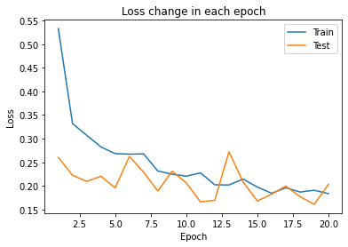

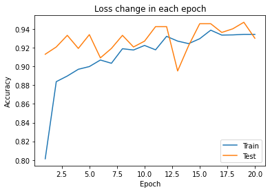

```python
plt.plot([1,2,3,4,5,6,7,8,9,10, 11, 12, 13, 14, 15, 16,17 ,18 ,19, 20], history.history["loss"])
plt.plot([1,2,3,4,5,6,7,8,9,10, 11, 12, 13, 14, 15, 16,17 ,18 ,19, 20], history.history["val_loss"])
plt.legend(["Train", "Test"])
plt.xlabel('Epoch')
plt.ylabel('Loss')
plt.title('Loss change in each epoch')
plt.show()
plt.plot([1,2,3,4,5,6,7,8,9,10, 11, 12, 13, 14, 15, 16,17 ,18 ,19, 20], history.history["accuracy"])
plt.plot([1,2,3,4,5,6,7,8,9,10, 11, 12, 13, 14, 15, 16,17 ,18 ,19, 20], history.history["val_accuracy"])
plt.legend(["Train", "Test"])
plt.xlabel('Epoch')
plt.ylabel('Accuracy')
plt.title('Loss change in each epoch')
plt.show()
```

Too little learning and the model will perform poorly on the training dataset and on new data. The model will underfit the problem. Too much learning and the model will perform well on the training dataset and poorly on new data, the model will overfit the problem. In both cases, the model has not generalized.

There are two ways to approach an overfit model:

- Reduce overfitting by training the network on more examples.
- Reduce overfitting by changing the complexity of the network.

## Regularization Methods for Neural Networks

The simplest and perhaps most common regularization method is to add a penalty to the loss function in proportion to the size of the weights in the model.

## Dropout

Dropout is a regularization method that approximates training a large number of neural networks with different architectures in parallel.

During training, some number of layer outputs are randomly ignored or “dropped out.” This has the effect of making the layer look-like and be treated-like a layer with a different number of nodes and connectivity to the prior layer. In effect, each update to a layer during training is performed with a different “view” of the configured layer.

## L1 and L2

A regression model that uses L1 regularization technique is called Lasso Regression and model which uses L2 is called Ridge Regression.

The key difference between these two is the penalty term.

Lasso Regression (Least Absolute Shrinkage and Selection Operator) adds “absolute value of magnitude” of coefficient as penalty term to the loss function.

## So why we got above results?

As we said, in drop out we drop some values. With this we are simplifying our data a lot. This is not good. Although we reduced noises but at the end for test data we can see that loss has been increased and accuracy has been decreased.

But about L2, also we can see above problem but it is not that much bad and at all we got very good result and this because of reducing noises and big changes in weights that was made by regularization.

At all, both regularization methods, made good result for us, because they removed big changes and we have less noises and this means we reduces overfitting.

# Conclusion: